# comparePhycoChla2014

Bryan Milstead

November 6, 2015

## To Do List

- everything

## Introduction

The goal is to compare the values of chla and phycocyanin. The expectation is that there should be a strong linear relationship (log log) between the two.

## Data

- get data from cyanoMon2014.mdb
- see CyanoMonDocumentation.Rmd
- Data Defintions

| Field | Data Type | Description |
| --- | --- | --- |
| **waterbodyID** | Short Text | Primary Key for this table. Unique ID for the Waterbody. Can either be entered by the users or will **stationID** |
| **sampleID** | AutoNumber | Primary Key for this table. Unique ID for the sample event |
| **sampleDate** | Short Date | Text Box: Date the sample was taken in format MM/DD/YYYY |
| **organization** | Short Text | Combo Box (“CRWA”; “CTDEEP”; “MEDEP”; “NHDES”;“RIWW”; “UNH_CFB”; “VTDEC”): Name of the organization in charge of visit; if more than one choose the primary |
| **sampleMethod** | Short Text | Combo Box (“Integrated Sampler”): should be Integrated Sampler but other values can be added. |
| **sampleDepthM** | Integer | Combo Box (1; 3): Depth (meters) sample was taken. Should be 1 or 3 meters but other values can be added. |
| **analysisID** | AutoNumber | Primary Key for this table. Unique ID for the analysis event |
| **analysisDate** | Short Date | Text Box: Date the sample was analyzed in format MM/DD/YYYY |
| **frozen** | Yes/No | Check Box: was sample frozen prior to analysis? |
| **filtered** | Yes/No | Check Box: was sample filtered prior to analysis? |
| **parameter** | Short Text | List Box/Radio Button (“nearShore”; “offShore”;“other”) |
| **reading** | Single | Text Box: Fluorometry reading |
| **units** | Short Text | List Box/Radio Button (“ug/l”; “RFU”): units of the fluorometry reading. |
| **rep** | Integer | replicate number for multiple readings from a sample |
| **fluorometerType** | Combo Box: (“Beagle”): this should be a Beagle but user can input other choices. |  |

## Build Dataset

- Get means for fluorometry readings to eliminate reps and duplicate; aggregate by c(‘analysisID’,‘parameter’,‘units’,‘fluorometerType’)
- merge Chla and Phycocyanin readings by c(‘analysisID’,‘units’,‘fluorometerType’)
- merge back to main dataset

## Analysis

- Based on Kasinak et al 2015 (Benchtop fluorometry of phycocyanin as a rapid approach for estimating cyanobacterial biovolume. Journal of Plankton Research 37(1): 248-257) We expect a strong log log relationship between Phycocyanin and Chlorophyll. Below is figure from their paper that demonstrates this

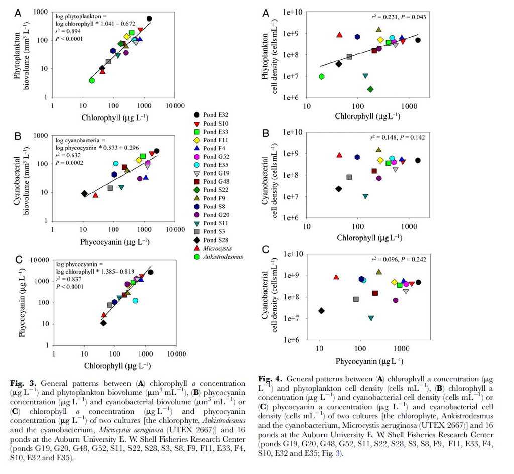

- Let’s plot Phycocyanin and Chlorophyll by sample condition and the Units that were reported
- First for the Beagle

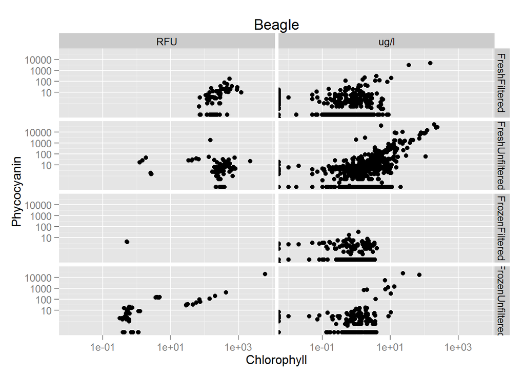

- As you can see the relationship varies by how the sample was processed and the units used for measurement.

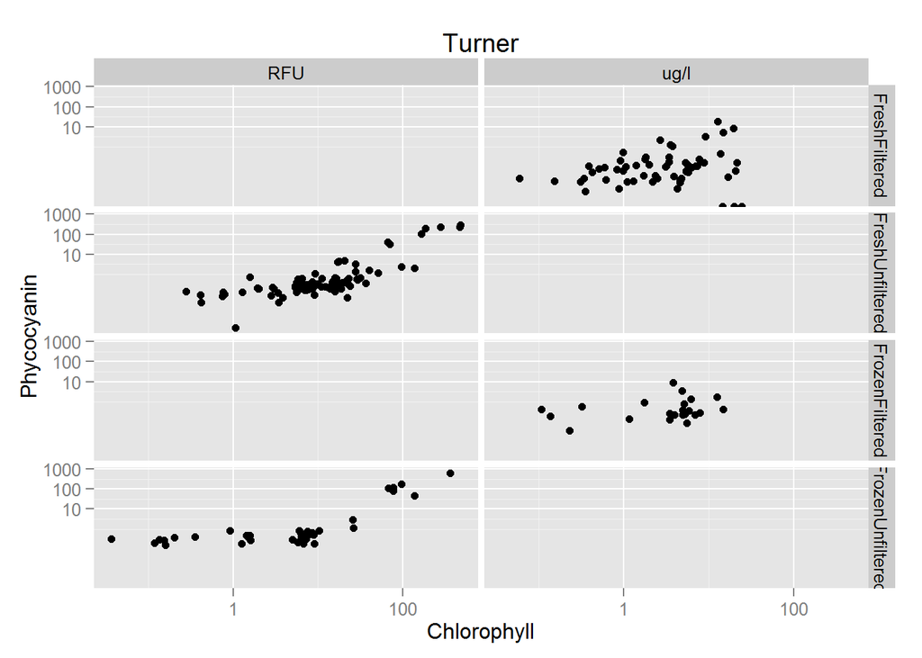

- The Turner data only come from Sonya Carlson and it appears there is a mistake in the units. Two of the plots use RFU and the other two ‘ug/l’. Need to check with Sonya about this.
- That said, the data look pretty good. Need to add some stats to make sure.
- What if we look at these relationships for the Beagle data by data source.

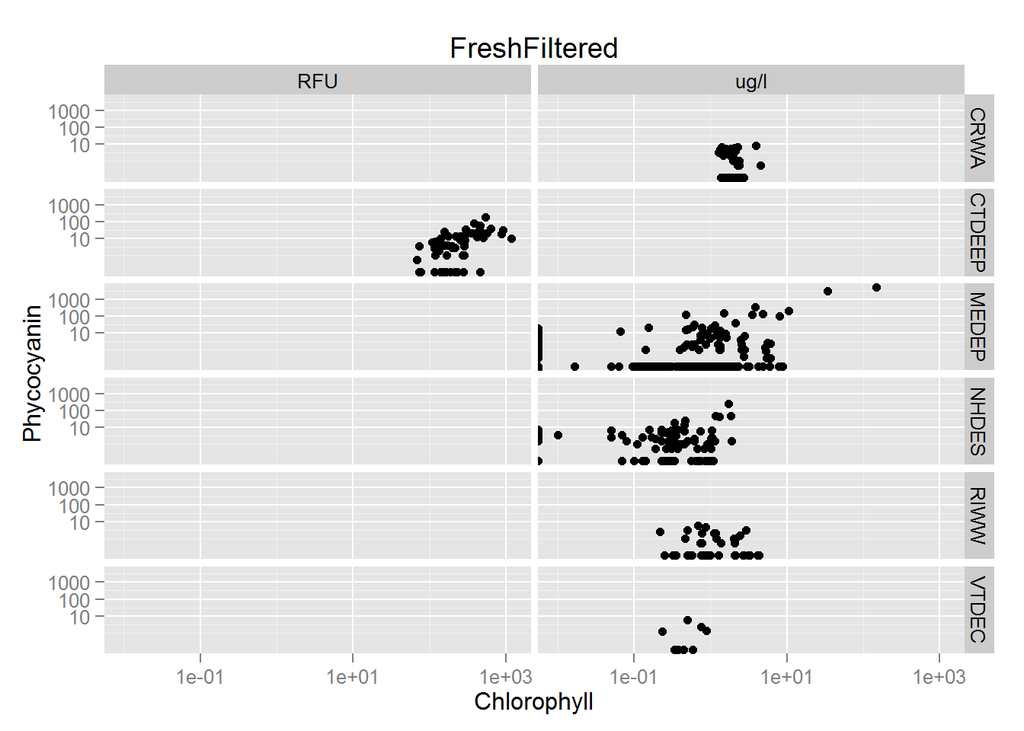

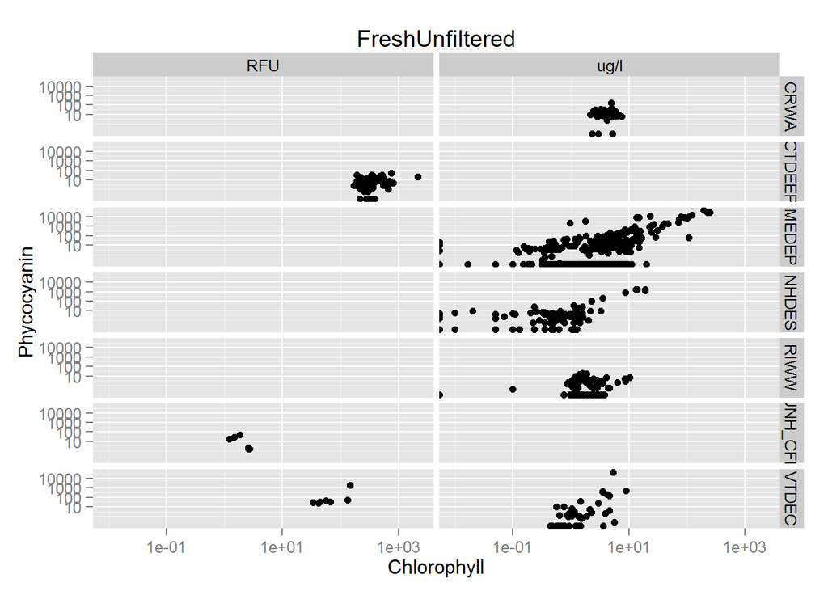

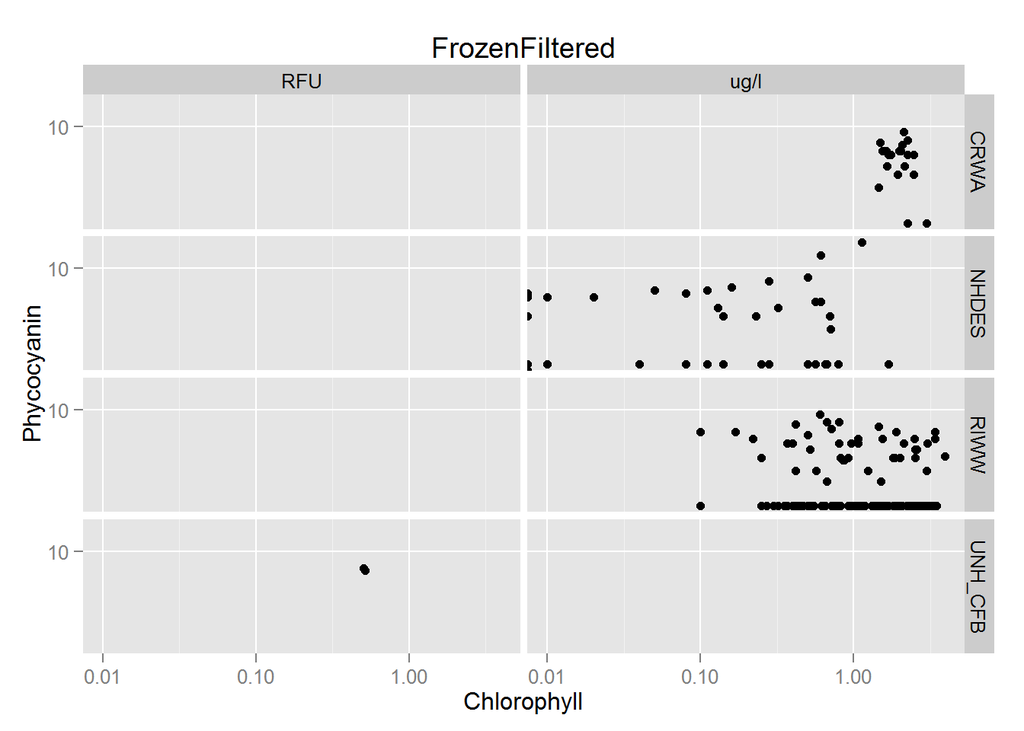

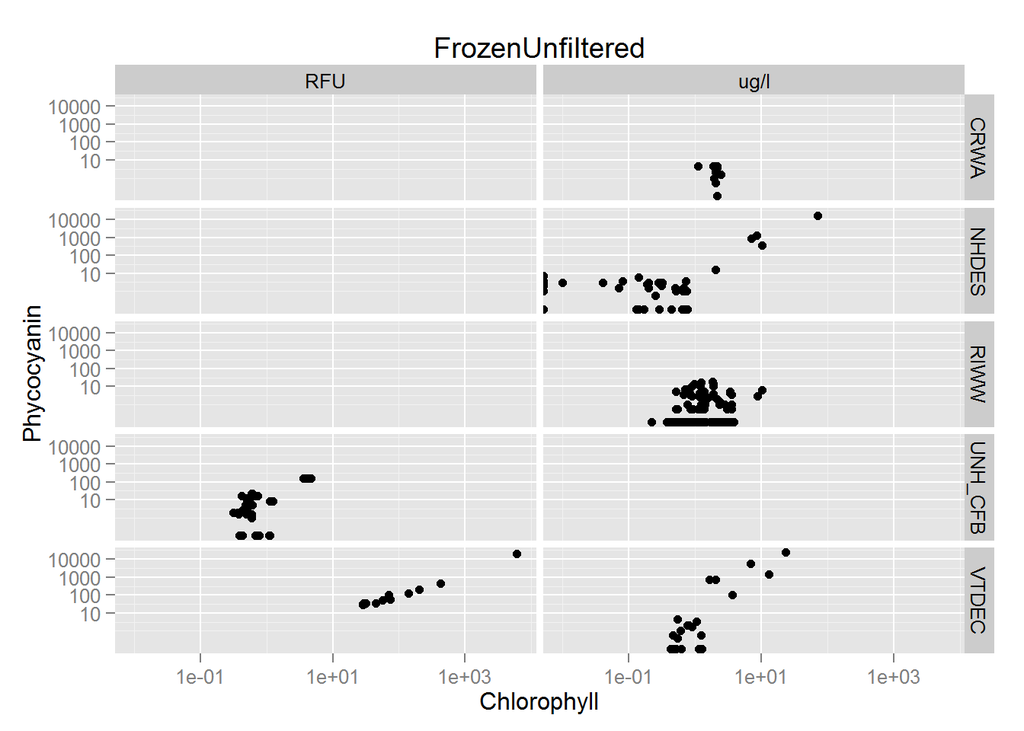

- Not sure how to interpret these. But it looks like we get very different results depending on the sample processing and the organization.